# Stress (CORT) response to witnessing attacks on a conspecific

Blake Jones, Adam Smith, Sara Bebus, Steve Shoech

19 October, 2015

# Experimental design summary

**See manuscript for more details** 18 test starlings (*Sturnus vulgaris*) observed, from a distance of 4 m, a conspecific lure experience one of three stressors (treatments) of interest:  
1. (control) Lure not attacked, but subjects sat in observation cages (with lure movement as in a raptor attack) for a randomly selected time (mean ± SD: 105.0 ± 25.1 min)  
2. (human) Observation of a human “attack” on a conspecific (mean ± SD: 100.7 ± 22.8 min)  
3. (raptor) Observation of a raptor attack (usually falcon) on a conspecific (mean ± SD: 108.0 ± 27.5 min)

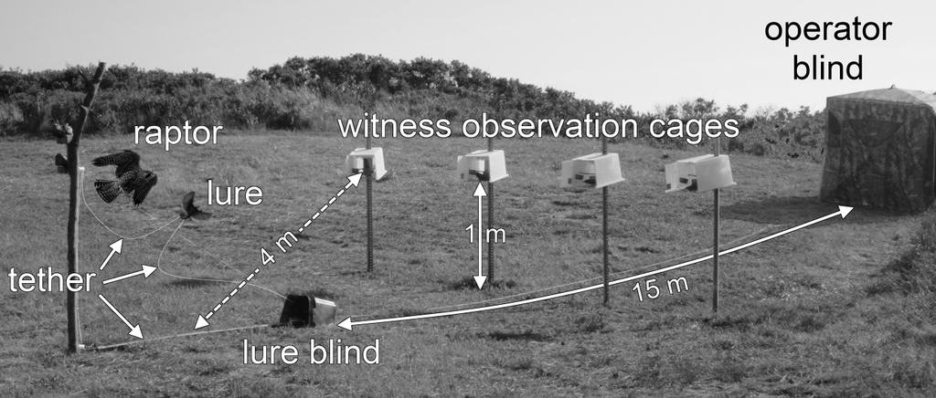

**Figure 1**. Experimental setup. See text for details.

# Statistical analysis summary

We used an 18-sequence, 4-period, 3-treatment crossover design, which allowed for the estimation of first-order carryover effects (i.e., residual effects due to the type of immediately preceding treatment) and the interactions between carryover and direct effects by considering “mixed” and “self” carryover effects (Kunert and Stufken, 2002). In each of the 18 unique treatment sequences, one treatment was repeated in two consecutive periods. That is, each treatment preceded every other treatment (“mixed”), as well as itself (“self”), the same number of times. This design further guaranteed that carryover effects were not confounded with treatment effects. Because period effects are common in crossover designs (e.g., acclimation to stressors), we designed sequences to guarantee that period effects were not confounded with treatment effects (i.e., each treatment occurred the same number of times in each of the four periods). We randomly assigned individuals to sequences.

We evaluated the effects of attack treatment on CORT levels using a linear mixed effects model in R (version 3.2.1; R Core Team 2015) with the “lme4” package (Bates et al., 2015). In addition to treatment, period, first-order carryover, and the type of first-order carryover effect (i.e., “self” or “mixed”), we allowed for a possible interaction between the type of carryover and first-order carryover effects. We also included four covariates in the analysis: the sex of the individual, the presence of active body or flight feather moult, time spent in the observation cage prior to the treatment, and witness baseline CORT level measured prior to the experiment. We did not evaluate the effect of age since most individuals were adults.

We estimated variances separately for each treatment to accommodate variance heterogeneity among the three treatments (Pinheiro and Bates, 2000). We included a random intercept for individuals, but excluded the random effect for the 26 attack and control events required to complete the experiment because there was no variability attributable to these events beyond residual variation. We report tests of fixed effects using the Kenward-Roger adjustment (Kenward and Roger, 1997) from the “pbkrtest” package (Halekoh and Højsgaard 2014) in R. We report Tukey adjusted pairwise comparisons and effect size estimates (Cohen’s d adjusted for matched measurements; Dunlop et al. 1996) between treatments.

To evaluate the similarity of CORT levels following exposure to a live predator attack upon a conspecific to those obtained in response to the capture-and-restraint protocol, we used two one-sided tests (TOST; Schuirmann, 1981; Westerlake, 1981) from the “equivalence” package (Robinson, 2014) in R. Additionally, we used TOST to evaluate the similarity of CORT levels following exposure to a control treatment to baseline levels obtained during the capture-and-restraint protocol. We considered mean CORT levels of witnesses to be equivalent if they differed by less than the standard deviation of the relevant capture-and-restraint CORT measurements (i.e., 3.6 ng/ml for the comparison of experimental control vs. baseline CORT levels and 11.0 ng/ml for the comparison of experimental raptor attack vs. capture-and-restraint stress-induced CORT levels).

Annotated R code:

## Load aliases, functions, and necessary packages

```r
source("./R/utils.R")

# Installing required packages
pkgs_need = c("gridExtra", "lme4", "pbkrtest", "equivalence", "plyr", "bbmle",
              "ggplot2", "gtable", "reshape2", "MuMIn", "lsmeans")
instant_pkgs(pkgs_need)

theme_set(theme_bw(base_size = 16))
```

## Load the data

Treatments (`trt`) are 1 (control), 2 (human), and 3 (raptor); `molt` is no/yes (0/1). `cort0` and `stress0` refer to the baseline and stress response measured before the experiment. `id` denotes the individual (n = 18). `event` records the grouping of individuals observing a given treatment (26 events necessary to complete the experiment). `attck_time` notes the length of time that individuals sat in observation cages prior to the treatment.

## Raw data plots

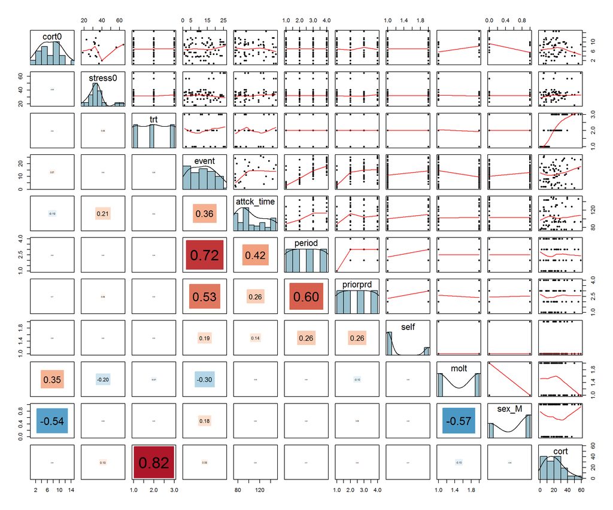

## Initial model fit and diagnostics

We first fit an initial `lmer` model that assumes homogeneous error.

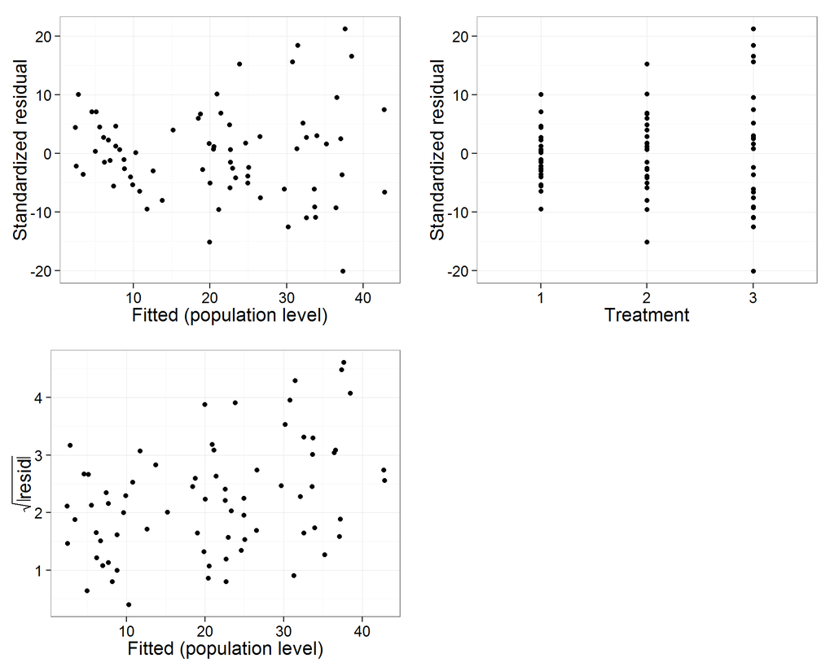

```r
# This first model allows random intercepts for individuals and treatment events
# Random effect variance for events is zero so simplify model to
# include only individual random effect variance
modBase <- lmer(cort ~ trt + period + self + prev_human + prev_raptor + self_human + self_raptor +
                 molt + sex + cort0 + attck_time + (1|id) + (1|event), data = dat)

# Fit simplified base model
modBase <- lmer(cort ~ trt + period + self + prev_human + prev_raptor + self_human + self_raptor +
                 molt + sex + cort0 + attck_time + (1|id), data = dat)

# Diagnostics from lmer model
# Population level residuals
grid.arrange(qplot(predict(modBase, re.form = NA), resid(modBase, type="pearson"),
                  xlab = "Fitted (population level)", ylab = "Standardized residual"),
          qplot(dat$trt, resid(modBase, type="pearson"), xlab = "Treatment",
                         ylab = "Standardized residual"),
          qplot(predict(modBase, re.form = NA), sqrt(abs(resid(modBase, type = "pearson"))),
                xlab = "Fitted (population level)", ylab=expression(sqrt(abs(resid)))),
          ncol = 2)
```

## Heterogeneous error model

The diagnostic plots from the base model indicate clear heteroscedacity in the residuals. The natural step to accomodate variance heterogeneity in this case is to allow separate variance estimates for each treatment. This greatly improves the model fit and, as illustrated next, model diagnostics.

```r
# First, create an observation-level factor variable
# This lets us specify variances separately by treatment
dat <- transform(dat, obs = factor(seq(nrow(dat))))

# Fit the variances separately by treatment
modId <- lmer(cort ~ trt + period + self + prev_human + prev_raptor + self_human + self_raptor +
                molt + sex + cort0 + attck_time + (1|id) + (0 + dummy(trt, "2")|obs) +
                (0 + dummy(trt, "3")|obs),
              control = lmerControl(check.nobs.vs.nlev="ignore",
                                check.nobs.vs.nRE="ignore"),
              data = dat)
AICctab(modBase, modId, nobs = nrow(dat), weights=T) # Heterogeneous strongly preferred
```

```
##         dAICc df weight
## modId    0.0  19 1
## modBase 14.1  17 <0.001
```

Model diagnostics are greatly improved in the heterogeous model.

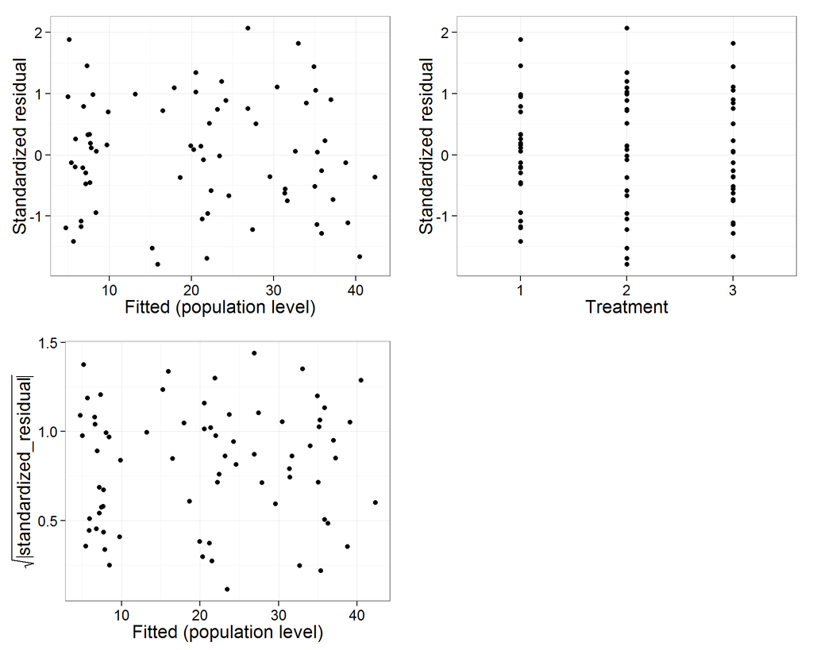

```r
# Get Pearson residuals
# Requires some manipulation of merMod object because of odd random effect structure
# specification necessary to fit heterogeneous model
resids_raw <- dat$cort - predict(modId, re.form = NA)
resids_p <- pres(resids_raw, as.character(dat$trt_name), modId)

grid.arrange(qplot(predict(modId, re.form = NA), resids_p,
                  xlab = "Fitted (population level)", ylab = "Standardized residual"),
          qplot(dat$trt, resids_p, xlab = "Treatment", ylab = "Standardized residual"),
          qplot(predict(modId, re.form = NA), sqrt(abs(resids_p)),
                xlab = "Fitted (population level)",
                ylab = expression(sqrt(abs(standardized_residual)))),
          ncol = 2)
```

## Assessment of fixed effects

First, we consider the necessity of the interaction between first order carryover effects (what was the previous treatment) and the general type of carryover effect (“self” vs. “mixed”). There’s not strong evidence of an interaction:

```
## F-test with Kenward-Roger approximation; computing time: 0.23 sec.
## large : cort ~ trt + period + self + prev_human + prev_raptor + self_human +
##     self_raptor + molt + sex + cort0 + attck_time + (1 | id) +
##     (0 + dummy(trt, "2") | obs) + (0 + dummy(trt, "3") | obs)
## small : cort ~ trt + period + self + prev_human + prev_raptor + molt +
##     sex + cort0 + attck_time + (1 | id) + (0 + dummy(trt, "2") |
##     obs) + (0 + dummy(trt, "3") | obs)
##          stat     ndf     ddf F.scaling p.value
## Ftest  0.7297  2.0000 39.2341    0.9911  0.4885
```

We drop this lone interaction and thus model only the additive effects of carryover (i.e., does the type of treatment in the previous period influence CORT response in the current treatment) and whether the previous treatment was the same as (“self” carryover) or different from (“mixed” carryover) the current treatment.

There is little evidence that CORT levels differed when the attack experienced in the preceding exposure was the same as the current exposure (“self” carryover) compared to when the prior attack was different from the current attack:

```
## F-test with Kenward-Roger approximation; computing time: 0.14 sec.
## large : cort ~ trt + period + self + prev_human + prev_raptor + molt +
##     sex + cort0 + attck_time + (1 | id) + (0 + dummy(trt, "2") |
##     obs) + (0 + dummy(trt, "3") | obs)
## small : cort ~ trt + period + prev_human + prev_raptor + molt + sex +
##     cort0 + attck_time + (1 | id) + (0 + dummy(trt, "2") | obs) +
##     (0 + dummy(trt, "3") | obs)
##          stat     ndf     ddf F.scaling p.value
## Ftest  1.6175  1.0000 31.7061         1  0.2127
```

nor is there much evidence that the treatment experienced in the prior treatment influences the CORT response of the current treatment. In other words, there is no indication of first-order carryover effects:

```
## F-test with Kenward-Roger approximation; computing time: 0.15 sec.
## large : cort ~ trt + period + self + prev_human + prev_raptor + molt +
##     sex + cort0 + attck_time + (1 | id) + (0 + dummy(trt, "2") |
##     obs) + (0 + dummy(trt, "3") | obs)
## small : cort ~ trt + period + self + molt + sex + cort0 + attck_time +
##     (1 | id) + (0 + dummy(trt, "2") | obs) + (0 + dummy(trt,
##     "3") | obs)
##          stat     ndf     ddf F.scaling p.value
## Ftest  1.8001  2.0000 30.9542   0.99397  0.1822
```

Similarly, the CORT response to a treatment did not vary consistently with when in the sequence (i.e., which period) the treatment occurred:

```
## F-test with Kenward-Roger approximation; computing time: 0.14 sec.
## large : cort ~ trt + period + self + prev_human + prev_raptor + molt +
##     sex + cort0 + attck_time + (1 | id) + (0 + dummy(trt, "2") |
##     obs) + (0 + dummy(trt, "3") | obs)
## small : cort ~ trt + self + prev_human + prev_raptor + molt + sex + cort0 +
##     attck_time + (1 | id) + (0 + dummy(trt, "2") | obs) + (0 +
##     dummy(trt, "3") | obs)
##         stat    ndf    ddf F.scaling p.value
## Ftest  1.714  3.000 22.297   0.99113  0.1929
```

## Nuisance covariates

Before addressing the treatment effects, note than none of the covariates (baseline CORT, molt, sex, attack time) associated strongly with CORT levels, although birds that sat in the observation cages for longer periods of time tended to have increased CORT levels. After adjustment to correct the denominator degrees of freedom (e.g., the Kenward-Roger approximation), the positive association between time spent in the observation cage and CORT response is marginal (*p* ~ 0.05).

```
## F-test with Kenward-Roger approximation; computing time: 0.28 sec.
## large : cort ~ trt + period + self + prev_human + prev_raptor + molt +
##     sex + cort0 + attck_time + (1 | id) + (0 + dummy(trt, "2") |
##     obs) + (0 + dummy(trt, "3") | obs)
## small : cort ~ trt + period + self + prev_human + prev_raptor + molt +
##     sex + attck_time + (1 | id) + (0 + dummy(trt, "2") | obs) +
##     (0 + dummy(trt, "3") | obs)
##         stat    ndf    ddf F.scaling p.value
## Ftest  1.433  1.000 13.445         1   0.252
```

```
## F-test with Kenward-Roger approximation; computing time: 0.13 sec.
## large : cort ~ trt + period + self + prev_human + prev_raptor + molt +
##     sex + cort0 + attck_time + (1 | id) + (0 + dummy(trt, "2") |
##     obs) + (0 + dummy(trt, "3") | obs)
## small : cort ~ trt + period + self + prev_human + prev_raptor + sex +
##     cort0 + attck_time + (1 | id) + (0 + dummy(trt, "2") | obs) +
##     (0 + dummy(trt, "3") | obs)
##          stat     ndf     ddf F.scaling p.value
## Ftest  0.0022  1.0000 13.9915         1  0.9632
```

```
## F-test with Kenward-Roger approximation; computing time: 0.09 sec.
## large : cort ~ trt + period + self + prev_human + prev_raptor + molt +
##     sex + cort0 + attck_time + (1 | id) + (0 + dummy(trt, "2") |
##     obs) + (0 + dummy(trt, "3") | obs)
## small : cort ~ trt + period + self + prev_human + prev_raptor + molt +
##     cort0 + attck_time + (1 | id) + (0 + dummy(trt, "2") | obs) +
##     (0 + dummy(trt, "3") | obs)
##          stat     ndf     ddf F.scaling p.value
## Ftest  1.5266  1.0000 14.2953         1  0.2365
```

```
## F-test with Kenward-Roger approximation; computing time: 0.09 sec.
## large : cort ~ trt + period + self + prev_human + prev_raptor + molt +
##     sex + cort0 + attck_time + (1 | id) + (0 + dummy(trt, "2") |
##     obs) + (0 + dummy(trt, "3") | obs)
## small : cort ~ trt + period + self + prev_human + prev_raptor + molt +
##     sex + cort0 + (1 | id) + (0 + dummy(trt, "2") | obs) + (0 +
##     dummy(trt, "3") | obs)
##          stat     ndf     ddf F.scaling p.value
## Ftest  4.2628  1.0000 23.2601         1 0.05028 .
## ---
## Signif. codes:  0 '***' 0.001 '**' 0.01 '*' 0.05 '.' 0.1 ' ' 1
```

## Treatment effects

In contrast to other covariates, there was very clear evidence that the stress response varied among treatments, and that responses to all treatments differed from each other. The evidence remains very strong after adjusting degrees of freedom:

```
## F-test with Kenward-Roger approximation; computing time: 0.11 sec.
## large : cort ~ trt + period + self + prev_human + prev_raptor + molt +
##     sex + cort0 + attck_time + (1 | id) + (0 + dummy(trt, "2") |
##     obs) + (0 + dummy(trt, "3") | obs)
## small : cort ~ period + self + prev_human + prev_raptor + molt + sex +
##     cort0 + attck_time + (1 | id) + (0 + dummy(trt, "2") | obs) +
##     (0 + dummy(trt, "3") | obs)
##         stat    ndf    ddf F.scaling   p.value
## Ftest 85.519  2.000 28.851   0.97681 7.472e-13 ***
## ---
## Signif. codes:  0 '***' 0.001 '**' 0.01 '*' 0.05 '.' 0.1 ' ' 1
```

```r
# Adjusted (least squares) means
as.data.frame(summary(lsmeans(modId2, ~ trt)))
```

```
##   trt    lsmean       SE       df  lower.CL upper.CL
## 1   1  9.693047 1.618606 40.83034  6.423793 12.96230
## 2   2 23.855330 2.033723 27.24663 19.684241 28.02642
## 3   3 37.132124 3.330899 30.80012 30.336923 43.92732
```

```r
# Paired (Tukey) differences
(paired_trt_diffs <- as.data.frame(summary(lsmeans(modId2, pairwise ~ trt)$contrast)))
```

```
##   contrast  estimate       SE       df    t.ratio      p.value
## 1    1 - 2 -14.16228 1.389263 22.29682 -10.194097 2.174966e-09
## 2    1 - 3 -27.43908 2.999222 22.82027  -9.148732 1.258956e-08
## 3    2 - 3 -13.27679 3.213328 29.01420  -4.131790 7.932772e-04
```

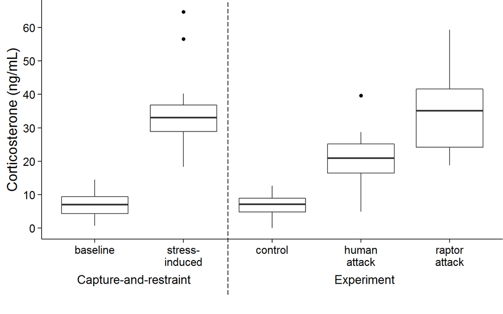

**Figure 2**. Total plasma corticosterone measured from 18 starlings during a pre-experimental standard handling stress series (baseline) and three experimental treatments. All samples were collected within 3 minutes of initial human contact. See text for a description of the pre-experiment stress series and experimental treatments.

### Effect sizes

CORT measurements after a raptor attack on CORT were approximately 2.6 and 1.4 standard deviations (Cohen’s *d*) greater than those after control and human attack, respectively. CORT measurements after a human attack were approximately 2 standard deviations greater than the control.

### Variance explained

The marginal (i.e., variance explained by fixed effects) *R*<sup>2</sup> values for our final linear mixed model, as defined by Nakagawa and Schielzeth (2013), is 0.59. We do not report the conditional R<sup>2</sup> given the slightly contrived random effects structure necessary to fit the heterogeneous variance model in `lme4`.

## Equivalence tests

We formally evaluate the equivalence of the stress response to a raptor attack to the handling stress response in the pre-experiment stress series. We do likewise for the stress response of the control treatment to the pre-experiment baseline stress response. Tests of equivalence require an *a priori* specification of how much measurements can differ and still be considered equivalent - we specify it as the standard deviation of the relevant pre-experiment stress series measurements. Thus, for the comparison of experimental control vs. capture-and-restraint baseline CORT, differences less than 3.6394821 ng/mL are considered biologically equivalent. For the comparison of experimental raptor attack vs. capture-and-restraint stress CORT, differences less than 10.9964158 ng/mL are considered biologically equivalent.

Two one-sided tests for equivalence (TOST; Schuirmann 1981, Westlake 1981) indicate that in both cases the experimental and capture-and-restraint measurements are equivalent as we have defined it. That is, the null hypothesis that the measurements were dissimilar was rejected in both cases (experimental control vs. capture-and-restraint baseline CORT: *p* = 0.016; experimental raptor attack vs. capture-and-restraint stress CORT: *p* = 0.007). It’s worth noting, perhaps, that a similar conclusion is reached using a “strict” paired t-test of equivalence (as defined by Wellek 2003).